# Lab_3_Levy_Eden_And_Esudri_Shira

1. (6pt) Use the library `rvest` to scrape all of William Shakespeare’s poems **titles** from [here](https://www.williamshakespeare.net/poems.jsp). You should end up with a `corpus` vector of 375 elements, where each element is a different poem title.
2. (6pt) When you click on each poem, you are transferred into a different url containing the poem’s text. For example, clicking on the first poem `A Fairy Song`, brings you [here](https://www.williamshakespeare.net/a-fairy-song.jsp). Parse the data and create a new vector variable `corpus_urls` containing the url for each poem. If you use the poem’s titles you may need to modify them to get the exact urls. You don’t have to be perfect here, and it is enough to get the correct urls for at least $300$ songs out of the $375$. Getting all songs urls correctly will yield a *bonus* of 1pt.
3. (6pt) Next we would like to retrieve the actual poems’ texts. Write a function called `poem_parser` that given a specific poem’s unparsed html page text, outputs the parsed poem as a string. For simplicity, leave in only letters and the minimum spaces required to differentiate between the different words. (no punctuations, special characters, etc.). Line starts can still be recognized by Uppercase letters. Run the function on the firs poem “A Fairy Song” and verify that the poem’s text is extracted correctly.
4. (5pt) Retrieve all the parsed poem texts into a vector called `poems`. Use your functions from (a.-c.).  
   *Note:* reading all poems may take a few minutes. Some errors may occur, but make sure that your poems urls (part b.) match and retrieve successfully at least $300$ out of the $375$ poems.
5. (9pt) Retrieve all words appearing in the poems and compute their frequencies. Plot the sorted word frequencies in descending order on a log-log scale.  
   We define a discrete probability distribution over the words where $p_w$ is the probability of word $w$ and $\sum_w p_w = 1$ where the sum is over all words $w$ appearing in any of the poems.  
   Let $r(w)$ is the rank of the word $w$ - that is, $r(w)=1$ for the most frequent word $w="\!\!the\!\!"$, $r(w)=2$ for the next frequent word etc.  
   According to [Zipf’s law](https://en.wikipedia.org/wiki/Zipf%27s_law), it is known that in English text the word frequencies follow roughly a *power law* distribution, with $p_w \approx a \times r(w)^b$ where $a, b$ are parameters of the distribution. Fit a linear regression line to the log-frequencies vs. log-rank data after *removing* all *singletons* (words appearing only once), and estimate $a$ and $b$ using this fit.
6. (5pt) Suppose that a Monkey types a sentence with *two* words by typing randomly one of the words from the poems, and then typing another one independently *with replacement*, and where the probability of each word is proportional to its frequency in the poems calculated in (e.). What is the probability that the same word will be typed twice? Answer using a Monte-carlo simulation with at least $10000$ random word-pairs. Can you calculate the probability exactly?
7. (5pt) Suppose that a Monkey types a sentence with six words by typing randomly one of the *words*: ‘to’, ‘be’, ‘or’, ‘not’, ‘to’, and ‘be’ *without replacement* (the words ‘to’ and ‘be’ appear twice). What is the probability that the Monkey will type the sentence ‘to be or not to be’? Perform a Monte-carlo simulation with at least $10000$ random sentences to estimate the probability. Can you calculate the probability exactly? When answering, please ignore spaces between words.
8. (4pt) What is the probability that a Monkey typing randomly one of the $26$ English *letters* one after the other (with replacement) will type on her first attempt the sentence ‘to be or not to be’? can you estimate it by sampling? explain (ignore spaces here too).
9. (5pt) Find the *shortest* poem from Shakespeare’s Corpus (in terms of total number of English characters). What is the probability that a monkey will randomly generate this poem when given a typewriter and typing letters like in (f.) ? (i.e. typing *words with replacement*). Ignore spaces, new lines, and Uppercase/lowercase letters.
10. (4pt) Find the poem that talks about summer, death, art, life, and chance.

A-

```r
#scrape all of William Shakespeare's poems title by Using the library rvest
shakespeare <- read_html("https://www.williamshakespeare.net/poems.jsp") #read the html poems page
corpus <- shakespeare %>% html_nodes('td') %>% html_text() # a vector that include all the poems that finish with "td" - 375 - Bonus :)
```

B -

```r
library(stringr)

urls <- html_attr(html_nodes(shakespeare, "tbody a"), "href") # a vector that gets all the urls from the poems page - 375 urls
urls <- sort(urls) # sort this vector by a-z first letter

corpus <- as.data.frame(corpus) # make this vector to data frame because we want to add a column of the urls

# a loop that add the initial of urls to the urls:
for(i in 1:length(urls)){
  urls[i] <- paste("https://www.williamshakespeare.net", urls[i], sep = "")
}
# add the column of urls to the corpus dataframe:
corpus$urls <- urls
```

C-

```r
library(htm2txt)
corpus$corpus <- tolower(corpus$corpus)

#function that input the title of the poem and output the poem:
poem_parser <- function(title){
  for(i in 1:length(corpus$urls)){
    if(title == corpus[i,1]){ #want the equal name of the input and the title
      txt <- gettxt(corpus[i,2]) #function that brings all the text from the url
      txt <- str_replace_all(txt, "[^[:alnum:]]", " " )  #remove punctuation
      txt <- gsub("   "," ",txt) #remove extra spaces
      txt <- gsub(".*by William Shakespeare  ","",txt) #remove all the words before (and include) "by William Shakespeare"
      txt <- gsub("Contact Us Terms of Use Privacy Policy Copyright 2015 Present www WilliamShakespeare net  All Rights Reserved","",txt) #remove the sentence that apears in all the ends of poems.
      txt <- gsub("  "," ",txt) #remove extra spaces
    }

  }
txt #print the poem to check if it works in the first poem
}

poem_parser("a fairy song")
```

```
## [1] "Over hill over dale Thorough bush thorough brier Over park over pale Thorough flood thorough fire I do wander everywhere Swifter than the moon s sphere And I serve the Fairy Queen To dew her orbs upon the green The cowslips tall her pensioners be In their gold coats spots you see Those be ru…
```

D-

```r
# vector of all the poems:
poems <- c() #empty vector
for(i in 1:length(corpus$urls)){
    poems <- c(poems, poem_parser(corpus$corpus[i])) #loop that merge all the poems to 1 vector, using the function from .c.

}
```

E-

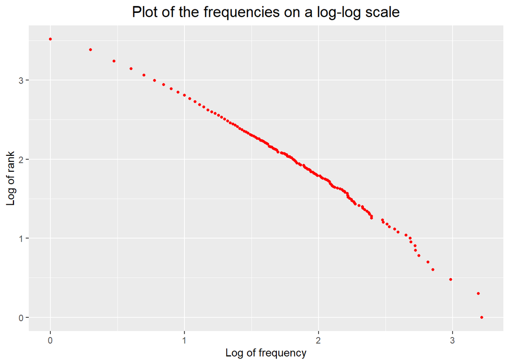

```r
#compute the frequency of the poems vector:
freq <- termFreq(poems) #function that compute frequency
freq <- sort(freq, decreasing = T) #sort the frequency from the high to low frequency
df_freq <- as.data.frame(freq) #data frame of the frequency because we want to add column
df_freq$words <- row.names(df_freq) # add column of the words for the forward sections

#add column of rank, according to the frequency:
df_freq$rank <- 0
rank <- 1
df_freq$rank[1] <- 1
for(i in 2:(length(df_freq$freq))){
  rank <- rank + 1
  ifelse(df_freq$freq[i-1] == df_freq$freq[i], df_freq$rank[i] <- df_freq$rank[i-1], df_freq$rank[i] <- rank)
}


#plot of the log of rank vs. log of frequency:
ggplot(data = df_freq, aes(x = log10(freq), y = log10(rank))) +
  geom_point(color = "red", size = 1) +
  theme_gray()+
  ggtitle('Plot of the frequencies on a log-log scale')+
  theme(plot.title = element_text(hjust = 0.5,size = 15)) + xlab("Log of frequency") +
  ylab("Log of rank")
```

```r
cat("We can see that the log-log scale shows us a linear graph, thanks to the log features that made the function linear")
```

```
## We can see that the log-log scale shows us a linear graph, thanks to the log features that made the function linear
```

```r
df_freq$p <- df_freq$freq / sum(df_freq$freq) #add column of the probability for each word

df_freq <- filter(.data = df_freq, freq >1 ) #remove all the words with frequency equal to 1

mdl <- lm(log(df_freq$freq) ~ log(df_freq$rank)) #model of the log(freq) and the explanatory variable the log frequency.

a <- mdl$coefficients[1] #the estimate of the Intercept of the model
b <- mdl$coefficients[2] #the estimate of the rank in the model

cat("We found that the estimate of a is:", a, "And the estimate of b is:", b)
```

```
## We found that the estimate of a is: 9.099775 And the estimate of b is: -1.069584
```

F -

```r
counter <- 0 #reset the counter
for(i in 1:10000){ #run on 10,000 times of this sample
  word_pairs_sample <- sample(df_freq$words, 2, prob = df_freq$p, replace = T) #sample 2 words independly with replacement
  if(word_pairs_sample[1] == word_pairs_sample[2]){ #count the pair that has equal word
    counter <- counter +1 #add one to the counter
  }
}
prob <- counter / 10000 #the probability

cat("The probability to get the same words in a pair in those specific 10,000 samples is: " , prob)
```

```
## The probability to get the same words in a pair in those specific 10,000 samples is:  0.0052
```

*We can’t calculate the probability exactly because everytime we sample 10,000 word pairs, we get different probability to get the same two words because the samples are different. If we did a sample of 100,000 or even 1,000,000, the probability was much closer in each time we were sample. The larger the number of samples, the more accurate the probability becomes.*

G -

```r
# sample this 6 words 10,000 times:
samples <- 10000
samp_words <- replicate(samples, sample(c("to", "be", "or", "not", "to", "be"), 6))

counter <- 0 #reset the counter
for(i in 1:10000){
  if(all(samp_words[,i] == c("to", "be", "or", "not", "to", "be"))){ #find equal sentences
    counter <- counter + 1 #add one to the counter
  }
}
prob <- counter / 10000 #the probability

cat("The probability to get this sentences in those specific 10,000 samples is: " , prob)
```

```
## The probability to get this sentences in those specific 10,000 samples is:  0.006
```

*We can’t calculate the probability exactly because everyאime we sample 10,000 sentences, we get different probability to get this exactly sentece because the samples are different. If we did a sample of 100,000 or even 1,000,000 (it takes a lot of running time), the probability was much closer in each time we were sample. The larger the number of samples, the more accurate the probability becomes.*

H -

```r
letters <-c("a" , "b", "c", "d", "e", "f", "g", "h", "i", "j", "k", "l", "m", "n", "o", "p", "q", "r", "s", "t", "u", "v", "w", "x", "y", "z") #all the a-b letters

our_sentence<-c("t", "o", "b", "e", "o", "r", "n", "o", "t", "t", "o", "b", "e") # the sentence in vector without spaces

first_attempt <- (1/26)^13 #the probability is close to zero. we didnt do round of 3 after dot because it is zero and we want you will see the exact probability

cat("The probability that the monkey will get this sentence in the first attempt is:", first_attempt)
```

```
## The probability that the monkey will get this sentence in the first attempt is: 0.0000000000000000004030384
```

*When we look at the exact probability we can see that it is close to zero, what means that it is almost impossible to get this sentence “to be or not to be” (without spaces) when we sampling 13 words at the first time. Because of this small probability we can’t make a sampling and find the estimate, because we need a huge sampling (even above milion) to get this sentence once (in the most cases) so the sampling here doesn’t working.*

I -

```r
corpus$poems <- poems #add the column of the poems to the data frame
min_words_poem <- 0 #reset the minimum
for(i in 1:length(corpus$poems)){
  words_of_poem <- nchar(corpus$poems[i], type = "chars", allowNA = FALSE, keepNA = NA) #count the number of characters
  if(min_words_poem > words_of_poem | min_words_poem == 0){ #condition to get the minimum
    min_words_poem <- words_of_poem #if the condition happens, the min become the smaller
    shortest_poem <- corpus$poems[i] #if the condition happens, the poem become the i poem
  }
}

num_of_letters <- str_count(shortest_poem, " ") #count the number of letters

cat("The shortest poem has:", min_words_poem, "words,", num_of_letters, "letters," , "and the poem is:", shortest_poem)
```

[output not shown]

```r
shortest_poem_vec <- strsplit(tolower(shortest_poem), " ") #make the shortest poem words to a vector

counter <- 0 #reset the counter
for(i in 1:10000){ #run on 10,000 times of this sample
  short_poem_sample <- sample(df_freq$words, 30, prob = df_freq$p, replace = T) #sample 30 words (like the shortest poem size)
  if(all(short_poem_sample == shortest_poem_vec[[1]])){ #count the vector that has equal words
    counter <- counter + 1 #add one to the counter if the condition happens
  }
}
prob <- counter / 10000 #the probability

cat("The probability that a monkey will randomly generate this poem is:", prob)
```

```
## The probability that a monkey will randomly generate this poem is: 0
```

*The probability that a monkey will randomly generate this poem is zero, also when we make a sample of 100,000 or 1,000,000. it is so rare, so even if we take infinity of samples, the probability will be zero or very close to zero.*

J -

```r
corpus$poems <- tolower(corpus$poems) #change all the poem to lower letters


#find the poem that include those words:
the_poem_op1 <- corpus %>% filter(str_detect(poems, ".+summer.+")) #filter only poems that include summer
the_poem_op1 <- corpus %>% filter(str_detect(poems, ".+death.+")) #filter only poems that include death
the_poem_op1 <- corpus %>% filter(str_detect(poems, ".+art.+")) #filter only poems that include art
the_poem_op1 <- corpus %>% filter(str_detect(poems, ".+life.+")) #filter only poems that include life
the_poem_op1 <- corpus %>% filter(str_detect(poems, ".+chance.+")) #filter only poems that include chance
the_poem_op1 [,1] # we dont know why but all the 5 first poems are the same
```

```
## [1] "sonnet 19: devouring time blunt thou the lion's paws"
## [2] "sonnet xxi"
## [3] "sonnets iii"
## [4] "sonnets xx"
## [5] "the blossom"
## [6] "under the greenwood tree"
```

```r
the_poem_op1[5,3]
```

```
## [1] "shall i compare thee to a summer s day thou art more lovely and more temperate rough winds do shake the darling buds of may and summer s lease hath all too short a date sometime too hot the eye of heaven shines and often is his gold complexion dimmed and every fair from fair sometime decline…
```

```r
#the_poem_op1 [6,3]  # We think you meant to this poem but it is not include "summer" so we dont know why it add this poem :)
```